# 內容介紹：

## Part 1 繪製圖形

- (1) 資料讀取與整理
- (2) 移動平均線 / K線圖
  - 介紹定義與公式
  - 自製移動平均線
- (3) 自定義圖形
  - 自定義寫法 1
  - 自定義寫法 2
- (4) MACD指標
  - 介紹定義與公式
  - 內建計算方式
- (5) RSI指標
  - 介紹定義與公式
  - 自製RSI線
- (6) 布林通道
  - 介紹定義與公式
  - 內建計算方式
- (7) KD指標
  - 介紹定義與公式
  - 自製KD線
- (8) 如何標記點
  - 標點範例

# 1-1 繪製圖形 - 資料讀取與整理

```python
import pandas as pd

#讀資料 (亞信3169) 2015年 - 2019年
stocks = pd.read_csv('stocks_3169.csv')

#印出資料(日期、開盤價、最高價、最低價、收盤價、成交量)
print(stocks)
```

[output not shown]

```python
import pandas as pd

#讀資料 (亞信3169) 2015年 - 2019年
stocks = pd.read_csv('stocks_3169.csv')

#印出資料(日期、開盤價、最高價、最低價、收盤價、成交量)
print(stocks)

#整理以及排列資料 1
stocks = stocks.set_index(pd.DatetimeIndex(stocks["Date"]))

#印出整理後的資料
print(stocks)
```

[output not shown]

```python
import pandas as pd

#讀資料 (亞信3169) 2015年 - 2019年
stocks = pd.read_csv('stocks_3169.csv')

#印出資料(日期、開盤價、最高價、最低價、收盤價、成交量)
print(stocks)

#整理以及排列資料 1
stocks.iloc[:, 0] = pd.to_datetime(stocks.iloc[:, 0], format = "%d/%m/%Y")

#印出整理後的資料
print(stocks)

#整理以及排列資料 2
stocks = stocks.set_index(pd.DatetimeIndex(stocks["Date"]))

#印出整理後的資料
print(stocks)
```

```
            Date   Open   High    Low  Close  Volume
0       5/1/2015  36.10  36.70  35.90  36.55    1367
1       6/1/2015  36.40  37.05  36.00  36.35    1272
2       7/1/2015  36.50  37.00  36.20  36.55    1038
3       8/1/2015  36.80  36.90  35.75  36.30     975
4       9/1/2015  36.50  36.75  36.15  36.15     767
...          ...    ...    ...    ...    ...     ...
1218  25/12/2019  36.45  37.40  36.40  37.30     249
1219  26/12/2019  37.30  38.15  37.00  38.10     357
1220  27/12/2019  37.85  38.40  37.55  38.10     246
1221  30/12/2019  38.15  38.90  37.90  37.90     280
1222  31/12/2019  37.90  38.10  37.60  37.95      95

[1223 rows x 6 columns]
           Date   Open   High    Low  Close  Volume
0    2015-01-05  36.10  36.70  35.90  36.55    1367
1    2015-01-06  36.40  37.05  36.00  36.35    1272
2    2015-01-07  36.50  37.00  36.20  36.55    1038
3    2015-01-08  36.80  36.90  35.75  36.30     975
4    2015-01-09  36.50  36.75  36.15  36.15     767
...         ...    ...    ...    ...    ...     ...
1218 2019-12-25  36.45  37.40  36.40  37.30     249
1219 2019-12-26  37.30  38.15  37.00  38.10     357
1220 2019-12-27  37.85  38.40  37.55  38.10     246
1221 2019-12-30  38.15  38.90  37.90  37.90     280
1222 2019-12-31  37.90  38.10  37.60  37.95      95

[1223 rows x 6 columns]
                 Date   Open   High    Low  Close  Volume
Date
2015-01-05 2015-01-05  36.10  36.70  35.90  36.55    1367
2015-01-06 2015-01-06  36.40  37.05  36.00  36.35    1272
2015-01-07 2015-01-07  36.50  37.00  36.20  36.55    1038
2015-01-08 2015-01-08  36.80  36.90  35.75  36.30     975
2015-01-09 2015-01-09  36.50  36.75  36.15  36.15     767
...               ...    ...    ...    ...    ...     ...
2019-12-25 2019-12-25  36.45  37.40  36.40  37.30     249
2019-12-26 2019-12-26  37.30  38.15  37.00  38.10     357
2019-12-27 2019-12-27  37.85  38.40  37.55  38.10     246
2019-12-30 2019-12-30  38.15  38.90  37.90  37.90     280
2019-12-31 2019-12-31  37.90  38.10  37.60  37.95      95

[1223 rows x 6 columns]
```

```python
import pandas as pd

#讀資料 (亞信3169)
stocks = pd.read_csv('stocks_3169.csv')

#整理以及排列資料
stocks.iloc[:, 0] = pd.to_datetime(stocks.iloc[:, 0], format = "%d/%m/%Y")
stocks = stocks.set_index(pd.DatetimeIndex(stocks["Date"]))

#取最新100筆資料
stocks.tail(100)

#印出資料
print(stocks)
```

```
                 Date   Open   High    Low  Close  Volume
Date
2015-01-05 2015-01-05  36.10  36.70  35.90  36.55    1367
2015-01-06 2015-01-06  36.40  37.05  36.00  36.35    1272
2015-01-07 2015-01-07  36.50  37.00  36.20  36.55    1038
2015-01-08 2015-01-08  36.80  36.90  35.75  36.30     975
2015-01-09 2015-01-09  36.50  36.75  36.15  36.15     767
...               ...    ...    ...    ...    ...     ...
2019-12-25 2019-12-25  36.45  37.40  36.40  37.30     249
2019-12-26 2019-12-26  37.30  38.15  37.00  38.10     357
2019-12-27 2019-12-27  37.85  38.40  37.55  38.10     246
2019-12-30 2019-12-30  38.15  38.90  37.90  37.90     280
2019-12-31 2019-12-31  37.90  38.10  37.60  37.95      95

[1223 rows x 6 columns]
```

# 1-2 繪製圖形 - 移動平均線 / K線圖

## 移動平均線定義：過去某段時間裡的平均成交價格

## 移動平均線公式：過去N天的收盤價加總除以N

```python
import mplfinance as mpf

#mpf內建可使用繪圖風格
print(mpf.available_styles())
```

```
['binance', 'blueskies', 'brasil', 'charles', 'checkers', 'classic', 'default', 'mike', 'nightclouds', 'sas', 'starsandstripes', 'yahoo']
```

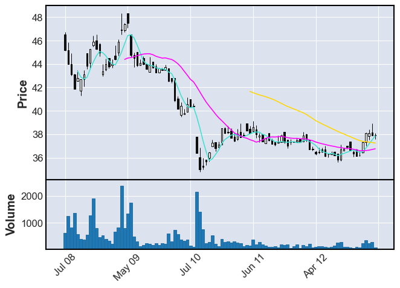

```python
import pandas as pd
import mplfinance as mpf

#讀資料 (亞信3169)
stocks = pd.read_csv('stocks_3169.csv')

#整理以及排列資料
stocks = stocks.set_index(pd.DatetimeIndex(stocks["Date"]))
stocks.iloc[:, 0] = pd.to_datetime(stocks.iloc[:, 0], format = "%d/%m/%Y")

#取最新100筆資料
stocks = stocks.tail(100)

#繪圖 (股票資料、印出成交量、設定風格(蠟燭圖)、移動平均線(5, 20, 60))
mpf.plot(stocks, volume = True, type = 'candle', mav = (5, 20, 60))
```

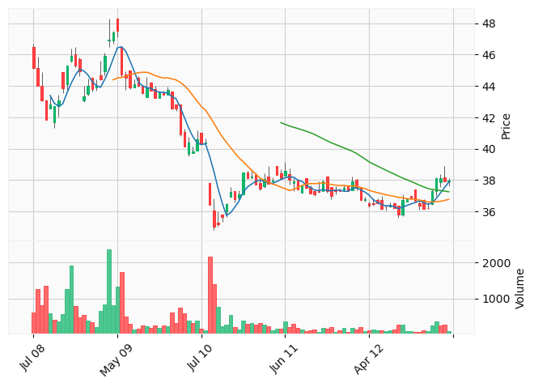

```python
mpf.plot(stocks, volume = True, type = 'candle', style = 'yahoo', mav = (5, 20, 60))
```

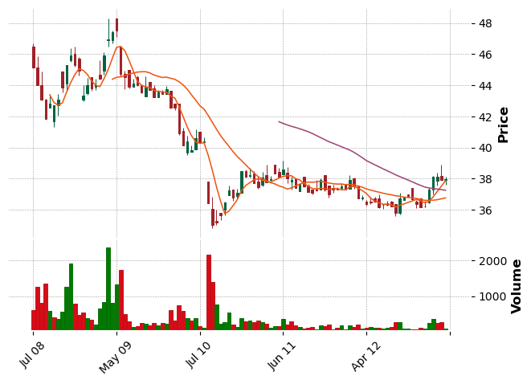

```python
mpf.plot(stocks, volume = True, type = 'candle', style = 'charles', mav = (5, 20, 60))
```

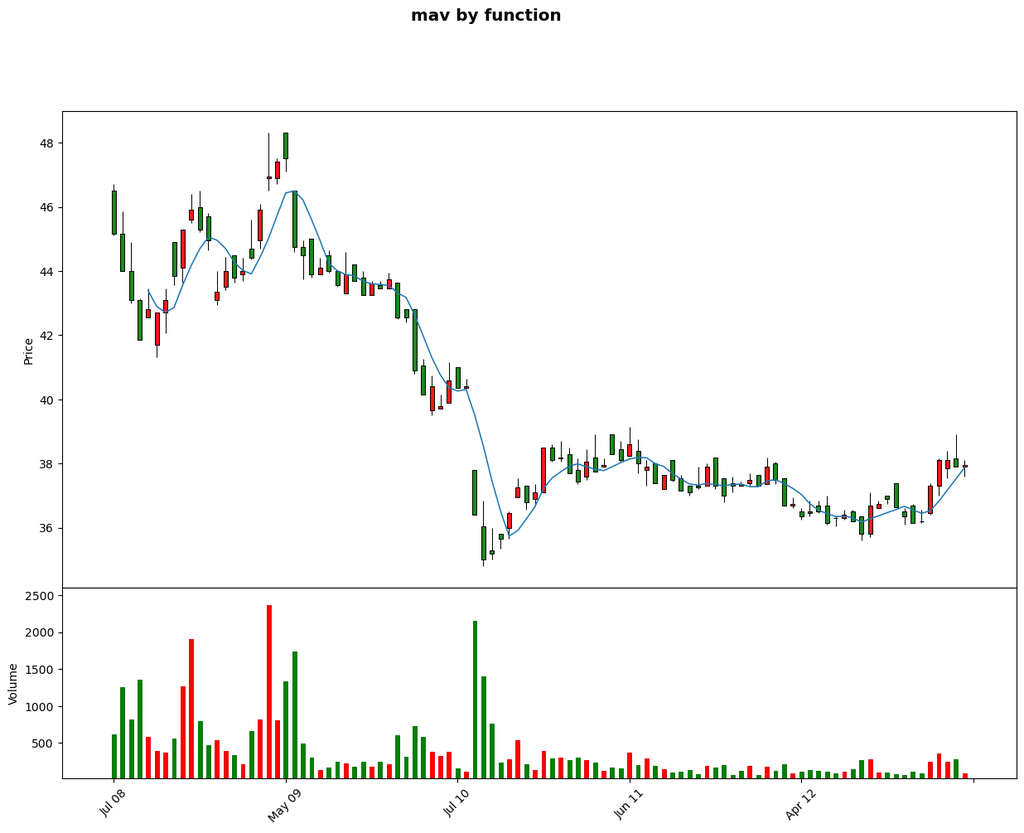

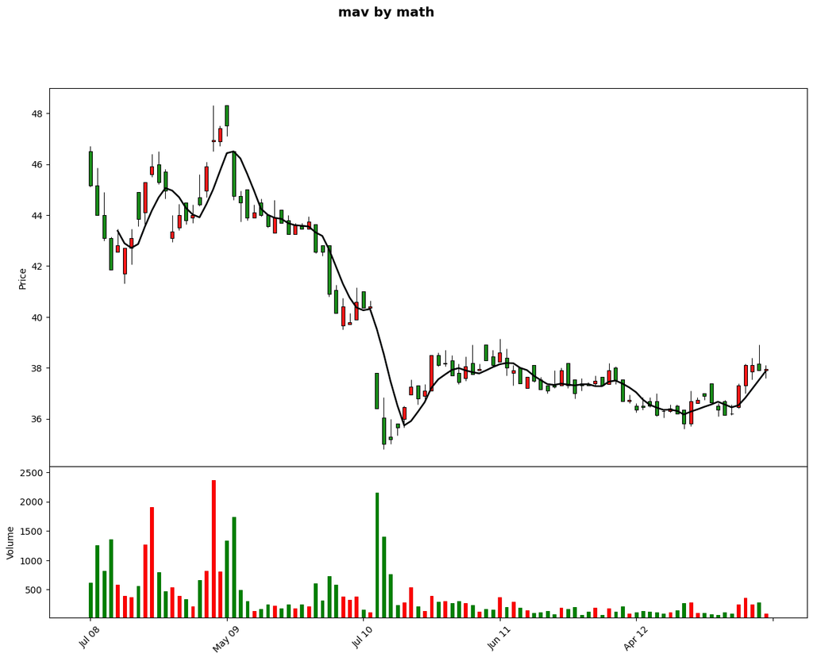

```python
#使用數學方式計算 5日線
import numpy as np
import pandas as pd
import mplfinance as mpf

#讀資料 (亞信3169) 20150105-20191231
stocks = pd.read_csv('stocks_3169.csv')

#整理以及排列資料
stocks = stocks.set_index(pd.DatetimeIndex(stocks["Date"]))
stocks.iloc[:, 0] = pd.to_datetime(stocks.iloc[:, 0], format = "%d/%m/%Y")

#取最新100筆資料
stocks = stocks.tail(100)

#自定義
#紅漲綠跌 (更改顏色)
colorSet = mpf.make_marketcolors(up = 'r', down = 'g', volume = 'inherit')

#style也要一起做更改
styleSet = mpf.make_mpf_style(marketcolors = colorSet)

#kwargs
kwargs = dict(type = 'candle', mav = 5, volume = True, figscale = 2,\
              style = styleSet, scale_width_adjustment = dict(volume = 0.5))

#繪圖 (上方的圖)
mpf.plot(stocks, **kwargs, title = 'mav by function')

#############################################################################

#stocks_close是近 100天收盤價的 list
stocks_close = [line for line in stocks['Close']]

#宣告陣列放置 5日線之值，前四個為 np.nan
five_mav = [np.nan] * 4

#計算五日平均線
for i in range(4, len(stocks_close)):
    five_mav.append( sum( stocks_close[ i-4 : i+1 ]) / 5 )

#使用 addplot
five = mpf.make_addplot(five_mav, color = 'black')

#將自製 5日線匯出 (下方的圖)
mpf.plot(stocks, **kwargs, addplot = five, title = 'mav by math')
```

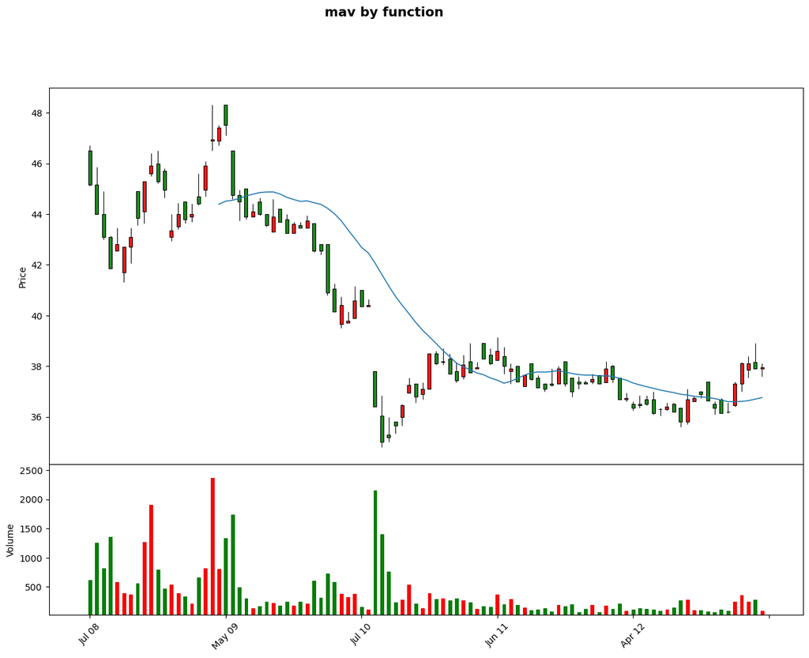

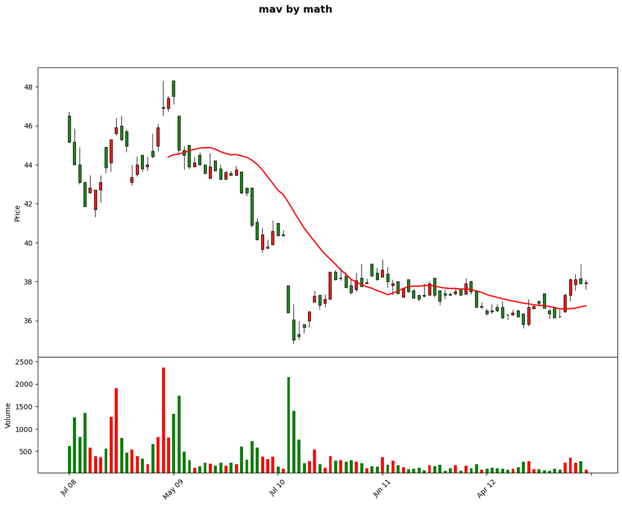

```python
#使用數學方式計算 20日線
import numpy as np
import pandas as pd
import mplfinance as mpf

#讀資料 (亞信3169) 20150105-20191231
stocks = pd.read_csv('stocks_3169.csv')

#整理以及排列資料
stocks = stocks.set_index(pd.DatetimeIndex(stocks["Date"]))
stocks.iloc[:, 0] = pd.to_datetime(stocks.iloc[:, 0], format = "%d/%m/%Y")

#取最新100筆資料
stocks = stocks.tail(100)

#客製化
#紅漲綠跌 (更改顏色)
colorSet = mpf.make_marketcolors(up = 'r', down = 'g', volume = 'inherit')

#style也要一起做更改
styleSet = mpf.make_mpf_style(marketcolors = colorSet)

#kwargs
kwargs = dict(type = 'candle', mav = 20, volume = True, figscale = 2,\
              style = styleSet, scale_width_adjustment = dict(volume = 0.5))

#繪圖 (上方的圖)
mpf.plot(stocks, **kwargs, title = 'mav by function')

#############################################################################

#stocks_close是進 100天收盤價的 list
stocks_close = [line for line in stocks['Close']]

#宣告陣列放置 20日線之值
twenty_mav = [np.nan] * 19

#計算二十日平均
for i in range(19, len(stocks_close)):
    twenty_mav.append( sum( stocks_close[i-19 : i+1]) / 20 )

#使用 addplot
twenty = mpf.make_addplot(twenty_mav, color = 'red')

#將自製 20日線匯出 (下方的圖)
mpf.plot(stocks, **kwargs, addplot = twenty, title = 'mav by math')
```

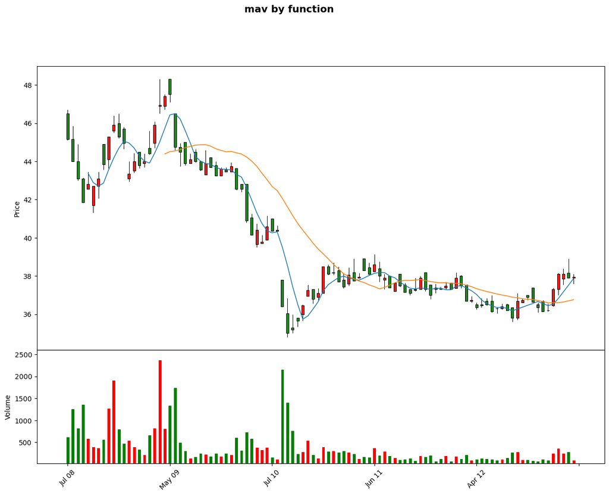

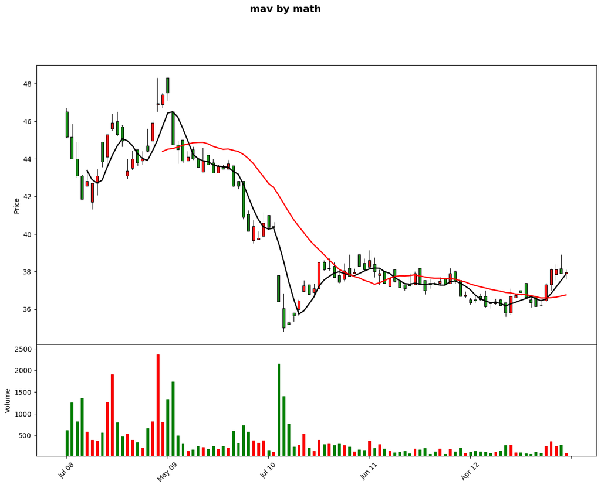

```python
#使用數學方式計算 n日線 - 函式版本
import numpy as np
import pandas as pd
import mplfinance as mpf

#讀資料 (亞信3169) 20150105-20191231
stocks = pd.read_csv('stocks_3169.csv')

#整理以及排列資料
stocks = stocks.set_index(pd.DatetimeIndex(stocks["Date"]))
stocks.iloc[:, 0] = pd.to_datetime(stocks.iloc[:, 0], format = "%d/%m/%Y")

#取最新100筆資料
stocks = stocks.tail(100)

#客製化
#紅漲綠跌 (更改顏色)
colorSet = mpf.make_marketcolors(up = 'r', down = 'g', volume = 'inherit')

#style也要一起做更改
styleSet = mpf.make_mpf_style(marketcolors = colorSet)

#kwargs
kwargs = dict(type = 'candle', mav = (5, 20), volume = True, figscale = 2,
    style = styleSet, scale_width_adjustment = dict(volume = 0.5))

#繪圖 (上方的圖)
mpf.plot(stocks, **kwargs, title = 'mav by function')

#############################################################################

#stocks_close是近 100天收盤價的 list
stocks_close = [line for line in stocks['Close']]

#開始寫函式
def making_averages(days):
    days_mav = [np.nan] * (days - 1)
    for i in range((days - 1), len(stocks_close)):
        days_mav.append( sum( stocks_close[i-(days - 1) : i+1]) / (days) )
    return days_mav

#############################################################################

#使用 addplot
addplots = [mpf.make_addplot(making_averages(5), color = 'black'),
            mpf.make_addplot(making_averages(20), color = 'red')]

#kwargs2
kwargs2 = dict(type = 'candle', volume = True, figscale = 2,
    style = styleSet, scale_width_adjustment = dict(volume = 0.5))

#將自製 5日線、20日線匯出 (下方的圖)
mpf.plot(stocks, **kwargs2, addplot = addplots, title = 'mav by math')
```

# 1-3 繪製圖形 - 自定義圖形

```
<Mpf_Figure size 2400x1000 with 0 Axes>
```

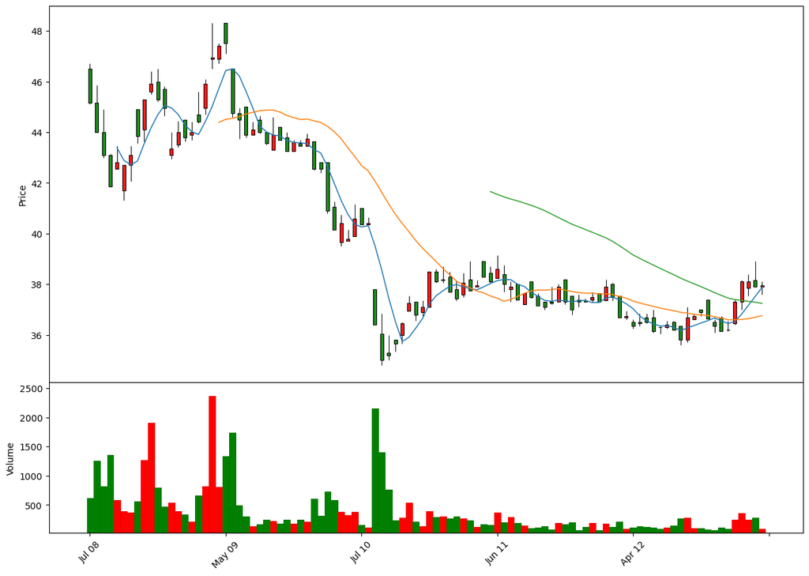

```python
#寫法1
import pandas as pd
import mplfinance as mpf

#讀資料 (亞信3169)
stocks = pd.read_csv('stocks_3169.csv')

#整理以及排列資料
stocks = stocks.set_index(pd.DatetimeIndex(stocks["Date"]))
stocks.iloc[:, 0] = pd.to_datetime(stocks.iloc[:, 0], format = "%d/%m/%Y")

#取最新100筆資料
stocks = stocks.tail(100)

#figure大小
mpf.figure(figsize = (24, 10))

#自定義
#紅漲綠跌 (更改顏色)
colorSet = mpf.make_marketcolors(up = 'r', down = 'g', volume = 'inherit')

#style
styleSet = mpf.make_mpf_style(marketcolors = colorSet)

#繪圖
mpf.plot(stocks, style = styleSet, type = 'candle', volume = True, mav = (5, 20, 60), figscale = 2)
```

```
<Mpf_Figure size 2400x1000 with 0 Axes>
```

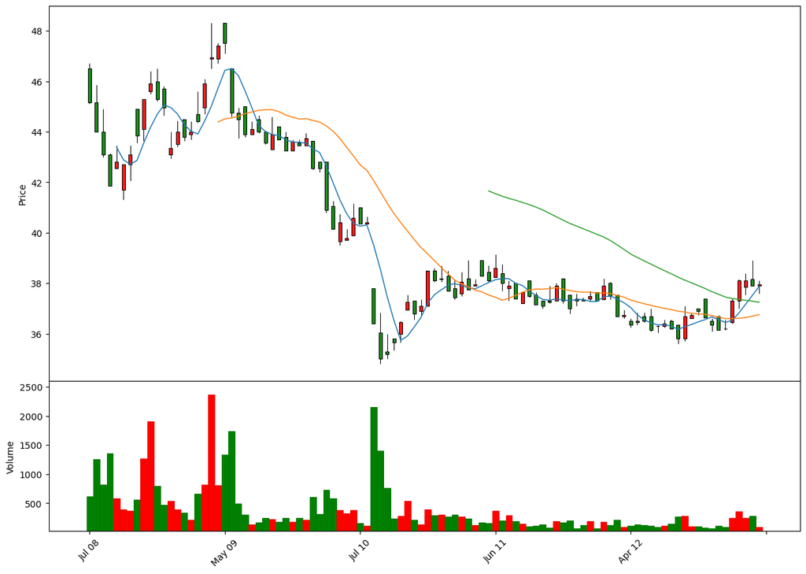

```python
##寫法2
import pandas as pd
import mplfinance as mpf

#讀資料 (亞信3169)
stocks = pd.read_csv('stocks_3169.csv')

#整理以及排列資料
stocks = stocks.set_index(pd.DatetimeIndex(stocks["Date"]))
stocks.iloc[:, 0] = pd.to_datetime(stocks.iloc[:, 0], format = "%d/%m/%Y")

#取最新100筆資料
stocks = stocks.tail(100)

#figure大小
mpf.figure(figsize = (24, 10))

#自定義
#紅漲綠跌 (更改顏色)
colorSet = mpf.make_marketcolors(up = 'r', down = 'g', volume = 'inherit')

#style
styleSet = mpf.make_mpf_style(marketcolors = colorSet)

#kwargs
kwargs = dict(type = 'candle', mav = (5, 20, 60), volume = True, style = styleSet, figscale = 2)

#繪圖
mpf.plot(stocks, **kwargs)
```

# 1-4 繪製圖形 - MACD指標 (Moving Average Convergence/Divergence)

### MACD指標定義：利用兩條不同的(快/慢)"指數移動平均線(EMA)"交錯來判斷股價走勢

### MACD指標公式：

#### 1. 首日EMA12 = 12天Close總和 / 12

#### 2. 首日EMA26 = 26天Close總和 / 26

#### 3. 非首日EMA12 = 前一天EMA12 *(11 / 13) + 今日Close* (2 / 13)

#### 4. 非首日EMA26 = 前一天EMA26 *(25 / 27) + 今日Close* (2 / 27)

#### 5. 差離值DIF = EMA12 - EMA26

#### 6. 首日MACD = 9天DIF總和 / 9

#### 7. 非首日MACD = 前一天MACD *(8 / 10) + 今日DIF* (2 / 10)

#### 8. 柱狀圖OSC = DIF - MACD

## References:

### How to install talib in python:

#### https://blog.quantinsti.com/install-ta-lib-python/#windows

### How to calculate MACD:

#### https://www.investopedia.com/ask/answers/122414/what-moving-average-convergence-divergence-macd-formula-and-how-it-calculated.asp

### Colors in python:

#### https://matplotlib.org/3.3.3/gallery/color/named_colors.html

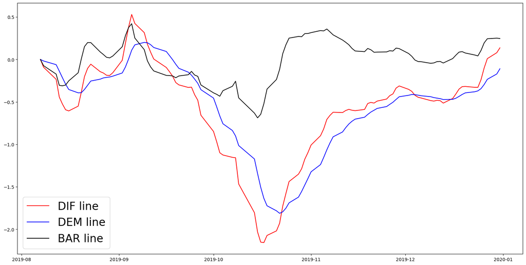

```python
import pandas as pd
import mplfinance as mpf
import matplotlib.pyplot as plt

stocks = pd.read_csv('stocks_3169.csv')

stocks.iloc[:, 0] = pd.to_datetime(stocks.iloc[:, 0], format = "%d/%m/%Y")
stocks = stocks.set_index(pd.DatetimeIndex(stocks["Date"]))

stocks = stocks.tail(100)

#製作MACD線圖
ema12 = stocks['Close'].ewm(span=12, adjust=False).mean() #12日移動平均線
ema26 = stocks['Close'].ewm(span=26, adjust=False).mean() #26日移動平均線
DIF  = ema12 - ema26                                      #快線
DEM = DIF.ewm(span = 9, adjust=False).mean()              #慢線
BAR = DIF - DEM                                           #柱狀圖

plt.figure(figsize = (20, 10))                            #圖片大小
plt.plot(DIF, label = 'DIF line', color = 'red')          #畫快線
plt.plot(DEM, label = 'DEM line', color = 'blue')         #畫慢線
plt.plot(BAR, label = 'BAR line', color = 'black')        #柱狀圖
plt.legend(fontsize = 24)                                 #圖例字體大小
plt.show()
```

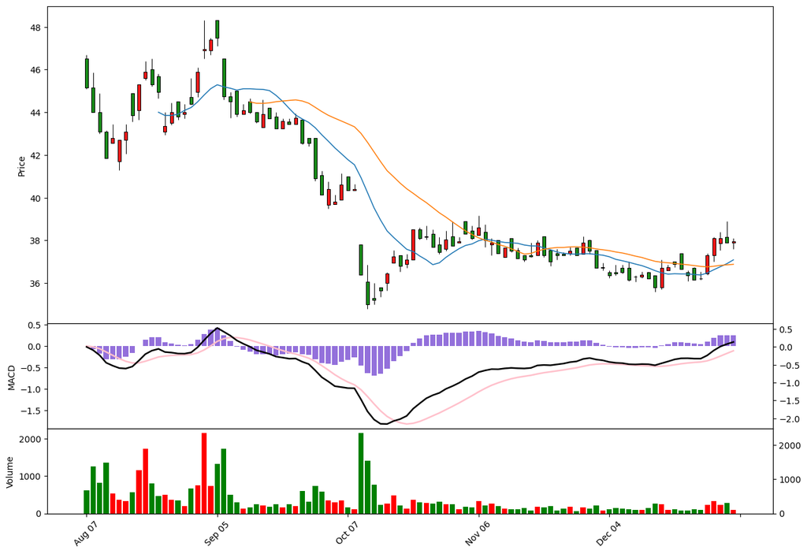

```python
#自定義
import pandas as pd
import mplfinance as mpf

stocks = pd.read_csv('stocks_3169.csv')

stocks.iloc[:, 0] = pd.to_datetime(stocks.iloc[:, 0], format = "%d/%m/%Y")
stocks = stocks.set_index(pd.DatetimeIndex(stocks["Date"]))

stocks = stocks.tail(100)

colorSet = mpf.make_marketcolors(up = 'r', down = 'g')

styleSet = mpf.make_mpf_style(marketcolors = colorSet)

kwargs = dict(type = 'candle', mav = (12, 26), style = styleSet, figscale = 2)

#製作MACD圖
ema12 = stocks['Close'].ewm(span=12, adjust=False).mean() #12日移動平均線
ema26 = stocks['Close'].ewm(span=26, adjust=False).mean() #26日移動平均線
DIF  = ema12 - ema26                                      #快線
DEM = DIF.ewm(span=9, adjust=False).mean()                #慢線
BAR = DIF - DEM                                           #柱狀圖

#成交量分顏色
stocks_volume_red = []
stocks_volume_green = []

for i in range(0, len(stocks['Volume'])):
    if(stocks['Open'][i] < stocks['Close'][i]):
        stocks_volume_red.append(int(stocks['Volume'][i]))
    else:
        stocks_volume_red.append(0)
    if(stocks['Open'][i] >= stocks['Close'][i]):
        stocks_volume_green.append(int(stocks['Volume'][i]))
    else:
        stocks_volume_green.append(0)

#panel: 從上到下 panel = 0, 1, 2...
#secondary_y = True -> 印出y軸
draw = [
            mpf.make_addplot(BAR, type = 'bar', panel = 1, color = 'mediumpurple', ylabel = 'MACD'),
            mpf.make_addplot(DIF, panel = 1, color = 'black'),
            mpf.make_addplot(DEM, panel = 1, color = 'pink'),
            mpf.make_addplot(stocks_volume_green, panel = 2, color = 'green', type = 'bar', ylabel = 'Volume'),
            mpf.make_addplot(stocks_volume_red, panel = 2, color = 'red', type = 'bar')
       ]

#panel_ratio -> 子圖大小比例
mpf.plot(stocks, **kwargs, addplot = draw, panel_ratios = (3, 1, 0.8))
```

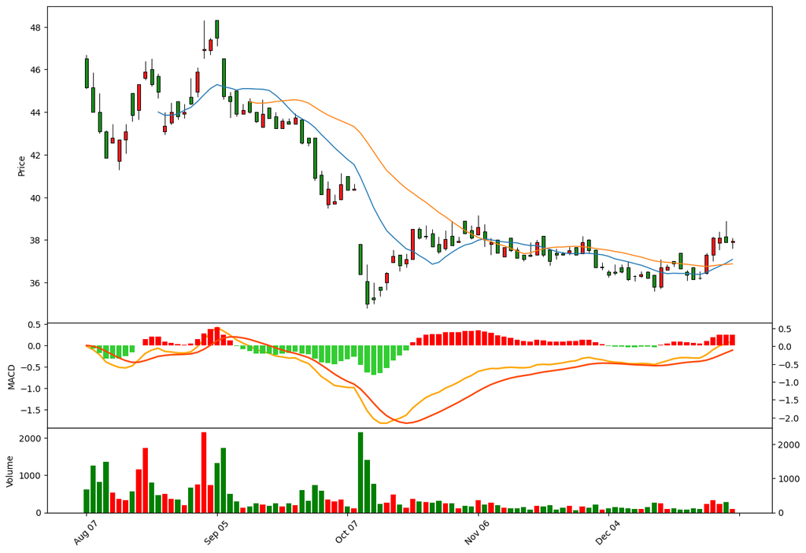

```python
#in general
import pandas as pd
import mplfinance as mpf

stocks = pd.read_csv('stocks_3169.csv')

stocks.iloc[:, 0] = pd.to_datetime(stocks.iloc[:, 0], format = "%d/%m/%Y")
stocks = stocks.set_index(pd.DatetimeIndex(stocks["Date"]))

stocks = stocks.tail(100)

colorSet = mpf.make_marketcolors(up = 'r', down = 'g', volume = 'inherit')

styleSet = mpf.make_mpf_style(marketcolors = colorSet)

kwargs = dict(type = 'candle', mav = (12, 26), style = styleSet, figscale = 2)

#製作MACD圖
ema12 = stocks['Close'].ewm(span=12, adjust=False).mean() #12日移動平均線
ema26 = stocks['Close'].ewm(span=26, adjust=False).mean() #26日移動平均線
DIF  = ema12 - ema26                                      #短期
DEM = DIF.ewm(span=9, adjust=False).mean()                #長期

#為了讓柱狀圖有不一樣顏色，分開成兩個不同的list，一個存正數，一個存負數
BAR = DIF - DEM
BAR[BAR < 0] = None
BAR_positive = BAR
BAR = DIF - DEM
BAR[BAR >= 0] = None
BAR_negative = BAR

#成交量分顏色
stocks_volume_red = []
stocks_volume_green = []

for i in range(0, len(stocks['Volume'])):
    if(stocks['Open'][i] < stocks['Close'][i]):
        stocks_volume_red.append(int(stocks['Volume'][i]))
    else:
        stocks_volume_red.append(0)
    if(stocks['Open'][i] >= stocks['Close'][i]):
        stocks_volume_green.append(int(stocks['Volume'][i]))
    else:
        stocks_volume_green.append(0)

#panel: 從上到下 panel = 0, 1, 2...
#secondary_y = True -> 印出y軸
draw = [
            mpf.make_addplot(BAR_negative, type = 'bar', panel = 1, color = 'limegreen', secondary_y = True, ylabel = 'MACD'),
            mpf.make_addplot(BAR_positive, type = 'bar', panel = 1, color = 'red', secondary_y = True, y_on_right = True),
            mpf.make_addplot(DIF, panel = 1, color = 'orange'),
            mpf.make_addplot(DEM, panel = 1, color = 'orangered'),
            mpf.make_addplot(stocks_volume_green, panel = 2, color = 'green', type = 'bar', ylabel = 'Volume'),
            mpf.make_addplot(stocks_volume_red, panel = 2, color = 'red', type = 'bar')
           ]

#panel_ratio -> 子圖大小比例
mpf.plot(stocks, **kwargs, addplot = draw, panel_ratios = (3, 1, 0.8))
```

# 1-5 繪製圖形 - RSI指標 (Relative Strength Index)

## RSI指標定義：判斷買賣雙方力道強弱的指標

## RSI指標公式：100 * 前N日漲幅平均值 / (前N日漲幅平均值 + 前N日跌幅平均值)

## Introduce and calculate RSI:

### https://handsoffinvesting.com/calculate-and-analyze-rsi-using-python/

```
[nan, -1.15, -0.9, -1.25, 0.95, -0.1, 0.4, 0.75, 1.45, 0.6, -0.6, -0.35, -1.6, 0.65, -0.2, 0.2, 0.4, 1.5, 1.05, 0.45, 0.1, -2.75, -0.25, -0.6, 0.2, -0.1, -0.45, 0.35, -0.2, -0.45, 0.35, -0.15, 0.3, -1.2, 0.0, -1.65, -0.75, 0.25, -0.6, 0.8, -0.25, 0.05, -4.0, -1.4, 0.2, 0.45, 0.8, 0.8, -0.45, 0.3, 1.…
[0, 0, 0, 0, 0.95, 0, 0.4, 0.75, 1.45, 0.6, 0, 0, 0, 0.65, 0, 0.2, 0.4, 1.5, 1.05, 0.45, 0.1, 0, 0, 0, 0.2, 0, 0, 0.35, 0, 0, 0.35, 0, 0.3, 0, 0, 0, 0, 0.25, 0, 0.8, 0, 0.05, 0, 0, 0.2, 0.45, 0.8, 0.8, 0, 0.3, 1.4, 0, 0.1, 0, 0, 0.6, 0, 0.2, 0.35, 0, 0.5, 0, 0, 0, 0.25, 0, 0, 0, 0.15, 0.65, 0, 0, 0.…
[0, -1.15, -0.9, -1.25, 0, -0.1, 0, 0, 0, 0, -0.6, -0.35, -1.6, 0, -0.2, 0, 0, 0, 0, 0, 0, -2.75, -0.25, -0.6, 0, -0.1, -0.45, 0, -0.2, -0.45, 0, -0.15, 0, -1.2, 0, -1.65, -0.75, 0, -0.6, 0, -0.25, 0, -4.0, -1.4, 0, 0, 0, 0, -0.45, 0, 0, -0.4, 0, -0.5, -0.25, 0, -0.3, 0, 0, -0.2, 0, -0.6, -0.1, -0.5…
```

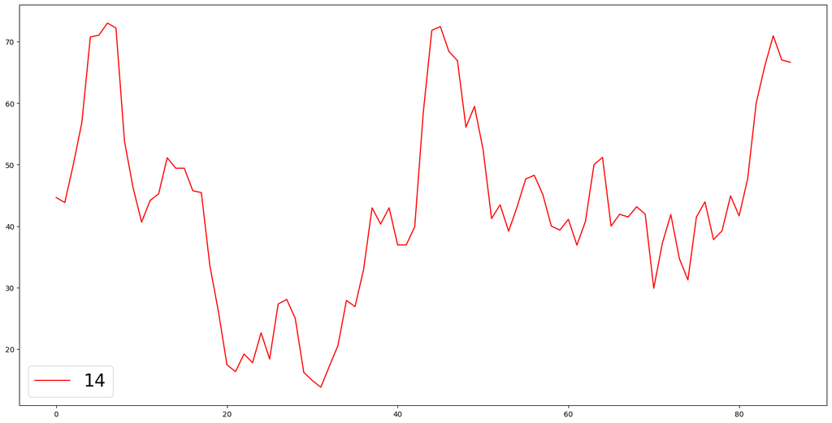

```python
#RSI 14
import numpy as np
import pandas as pd
import matplotlib.pyplot as plt
stocks = pd.read_csv('stocks_3169.csv')

stocks.iloc[:, 0] = pd.to_datetime(stocks.iloc[:, 0], format = "%d/%m/%Y")
stocks = stocks.set_index(pd.DatetimeIndex(stocks["Date"]))

stocks = stocks.tail(100)

#計算RSI
stocks_close = [float(line) for line in stocks['Close']]
delta = [np.nan] #存差值
up = []          #存 >0 的差值
down = []        #存 <0 的差值
rsi = []         #存RSI的值

#計算差值
for i in range(1, 100):
    delta.append(round(stocks_close[i] - stocks_close[i - 1], 2))

#分別放進差值 (<0, >0)
for value in delta:
    up.append(value if value > 0 else 0)
    down.append(value if value < 0 else 0)

#計算前14日漲幅平均值、前14日跌幅平均值
for i in range(13, 100):
    gain = sum(up[i - 13 : i + 1]) / 14
    lost = abs(sum(down[i - 13 : i + 1])) / 14
    rsi.append(100 * gain / (gain + lost))

#測試，印出差值
print(delta)
#測試、只印出 >0 的差值
print(up)
#測試、只印出 <0 的差值
print(down)

plt.figure(figsize = (20, 10))
plt.plot(rsi, label = '14', color = 'red')
plt.legend(fontsize = 24)
plt.show()
```

```
[nan, -1.15, -0.9, -1.25, 0.95, -0.1, 0.4, 0.75, 1.45, 0.6, -0.6, -0.35, -1.6, 0.65, -0.2, 0.2, 0.4, 1.5, 1.05, 0.45, 0.1, -2.75, -0.25, -0.6, 0.2, -0.1, -0.45, 0.35, -0.2, -0.45, 0.35, -0.15, 0.3, -1.2, 0.0, -1.65, -0.75, 0.25, -0.6, 0.8, -0.25, 0.05, -4.0, -1.4, 0.2, 0.45, 0.8, 0.8, -0.45, 0.3, 1.…
[0, 0, 0, 0, 0.95, 0, 0.4, 0.75, 1.45, 0.6, 0, 0, 0, 0.65, 0, 0.2, 0.4, 1.5, 1.05, 0.45, 0.1, 0, 0, 0, 0.2, 0, 0, 0.35, 0, 0, 0.35, 0, 0.3, 0, 0, 0, 0, 0.25, 0, 0.8, 0, 0.05, 0, 0, 0.2, 0.45, 0.8, 0.8, 0, 0.3, 1.4, 0, 0.1, 0, 0, 0.6, 0, 0.2, 0.35, 0, 0.5, 0, 0, 0, 0.25, 0, 0, 0, 0.15, 0.65, 0, 0, 0.…
[0, -1.15, -0.9, -1.25, 0, -0.1, 0, 0, 0, 0, -0.6, -0.35, -1.6, 0, -0.2, 0, 0, 0, 0, 0, 0, -2.75, -0.25, -0.6, 0, -0.1, -0.45, 0, -0.2, -0.45, 0, -0.15, 0, -1.2, 0, -1.65, -0.75, 0, -0.6, 0, -0.25, 0, -4.0, -1.4, 0, 0, 0, 0, -0.45, 0, 0, -0.4, 0, -0.5, -0.25, 0, -0.3, 0, 0, -0.2, 0, -0.6, -0.1, -0.5…
```

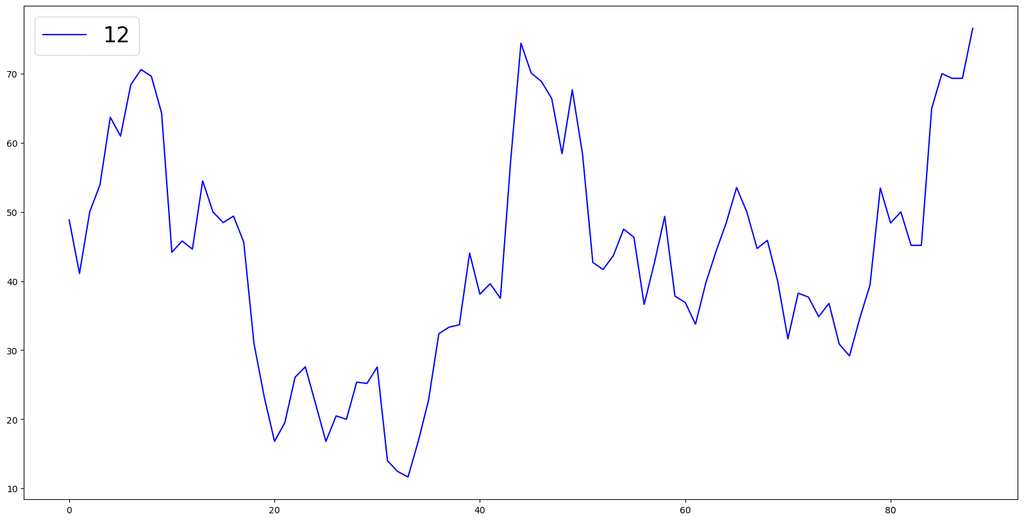

```python
#RSI 12
import numpy as np
import pandas as pd
import matplotlib.pyplot as plt
stocks = pd.read_csv('stocks_3169.csv')

stocks.iloc[:, 0] = pd.to_datetime(stocks.iloc[:, 0], format = "%d/%m/%Y")
stocks = stocks.set_index(pd.DatetimeIndex(stocks["Date"]))

stocks = stocks.tail(100)

#計算RSI
stocks_close = [float(line) for line in stocks['Close']]
delta = [np.nan] #存差值
up = []          #存 >0 的差值
down = []        #存 <0 的差值
rsi = []         #存RSI的值

#計算差值
for i in range(1, 100):
    delta.append(round(stocks_close[i] - stocks_close[i - 1], 2))

#分別放進差值 (<0, >0)
for value in delta:
    up.append(value if value > 0 else 0)
    down.append(value if value < 0 else 0)

#計算前12日漲幅平均值、前12日跌幅平均值
for i in range(11, 100):
    gain = sum(up[i - 11 : i + 1]) / 14
    lost = abs(sum(down[i - 11 : i + 1])) / 14
    rsi.append(100 * gain / (gain + lost))

#測試，印出差值
print(delta)
#測試、只印出 >0 的差值
print(up)
#測試、只印出 <0 的差值
print(down)

plt.figure(figsize = (20, 10))
plt.plot(rsi, label = '12', color = 'blue')
plt.legend(fontsize = 24)
plt.show()
```

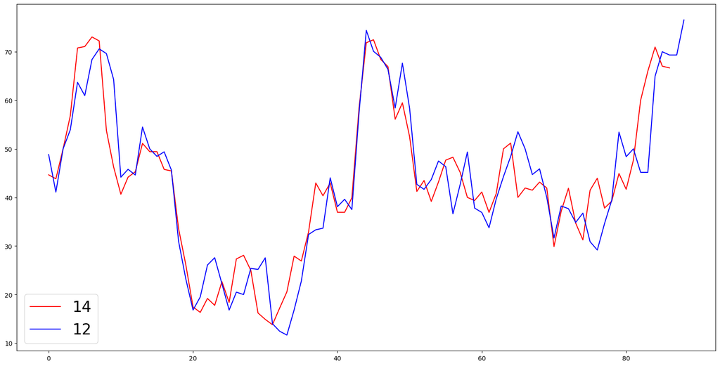

```python
#做成函式
import numpy as np
import pandas as pd
import matplotlib.pyplot as plt
stocks = pd.read_csv('stocks_3169.csv')

stocks.iloc[:, 0] = pd.to_datetime(stocks.iloc[:, 0], format = "%d/%m/%Y")
stocks = stocks.set_index(pd.DatetimeIndex(stocks["Date"]))

stocks = stocks.tail(100)

#############################################################################

def rsiLine(period):
    stocks_close = [float(line) for line in stocks['Close']]
    delta = [np.nan]
    up = []
    down = []
    rsi = []

    for i in range(1, 100):
        delta.append(round(stocks_close[i] - stocks_close[i - 1], 2))
    for value in delta:
        up.append(value if value > 0 else 0)
        down.append(value if value < 0 else 0)
    for i in range(period - 1, 100):
        gain = sum(up[i - (period - 1) : i + 1]) / period
        lost = abs(sum(down[i - (period - 1) : i + 1])) / period
        rsi.append(100 * gain / (gain + lost))
    return rsi

#############################################################################

plt.figure(figsize = (20, 10))
plt.plot(rsiLine(14), label = '14', color = 'red')
plt.plot(rsiLine(12), label = '12', color = 'blue')
plt.legend(fontsize = 24)
plt.show()
```

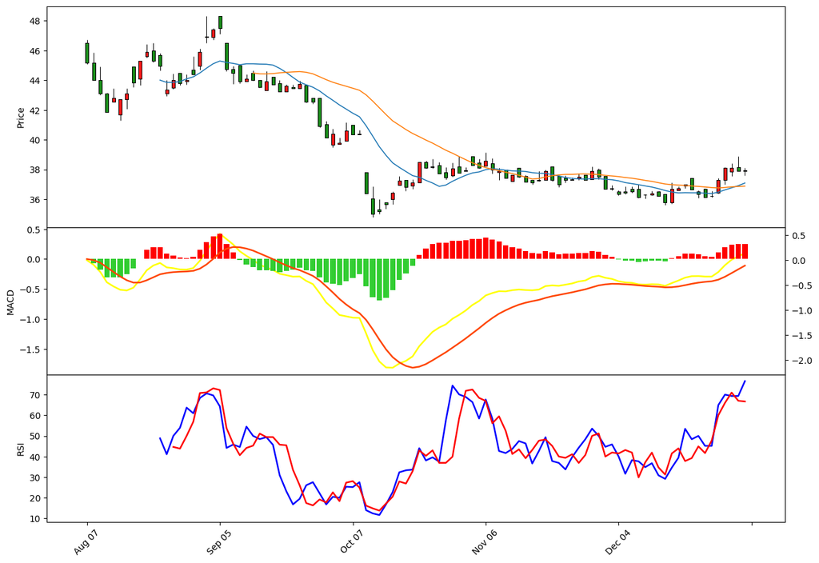

```python
#in general
import pandas as pd
import mplfinance as mpf
import numpy as np

stocks = pd.read_csv('stocks_3169.csv')

stocks.iloc[:, 0] = pd.to_datetime(stocks.iloc[:, 0], format = "%d/%m/%Y")
stocks = stocks.set_index(pd.DatetimeIndex(stocks["Date"]))

stocks = stocks.tail(100)

colorSet = mpf.make_marketcolors(up = 'r', down = 'g', inherit = False)

styleSet = mpf.make_mpf_style(marketcolors = colorSet)

kwargs = dict(type = 'candle', mav = (12, 26), style = styleSet, figscale = 2)

#製作MACD圖
ema12 = stocks['Close'].ewm(span=12, adjust=False).mean() #12日移動平均線
ema26 = stocks['Close'].ewm(span=26, adjust=False).mean() #26日移動平均線
DIF  = ema12 - ema26                                      #短期
DEM = DIF.ewm(span=9, adjust=False).mean()                #長期

#為了讓柱狀圖有不一樣顏色，分開成兩個不同的list，一個存正數，一個存負數
BAR = DIF - DEM
BAR[BAR < 0] = None
BAR_positive = BAR
BAR = DIF - DEM
BAR[BAR >= 0] = None
BAR_negative = BAR

#製作RSI線圖
def rsiLine(period):
    stocks_close = [float(line) for line in stocks['Close']]
    delta = [np.nan]
    up = []
    down = []
    rsi = [np.nan] * (period - 1)

    for i in range(1, 100):
        delta.append(round(stocks_close[i] - stocks_close[i - 1], 2))
    for value in delta:
        up.append(value if value > 0 else 0)
        down.append(value if value < 0 else 0)
    for i in range(period - 1, 100):
        gain = sum(up[i - (period - 1) : i + 1]) / period
        lost = abs(sum(down[i - (period - 1) : i + 1])) / period
        rsi.append(100 * gain / (gain + lost))
    return rsi

draw = [
            mpf.make_addplot(BAR_negative, type = 'bar', panel = 1, color = 'limegreen', secondary_y = True, ylabel = 'MACD'),
            mpf.make_addplot(BAR_positive, type = 'bar', panel = 1, color = 'red', secondary_y = True, y_on_right = True),
            mpf.make_addplot(DIF, panel = 1, color = 'yellow'),
            mpf.make_addplot(DEM, panel = 1, color = 'orangered'),
            mpf.make_addplot(rsiLine(12), panel = 2, color = 'blue', ylabel = 'RSI'),
            mpf.make_addplot(rsiLine(14), panel = 2, color = 'red'),
       ]

mpf.plot(stocks, **kwargs, addplot = draw, panel_ratios = (3, 2, 2))
```

# 1-6 繪製圖形 - 布林通道 (Bollinger Bands)

## What is Bollinger Bands:

### https://histock.tw/blog/histock1688/43

## Introduce TA-Lib:

### https://kknews.cc/zh-tw/invest/pyyvkjz.html

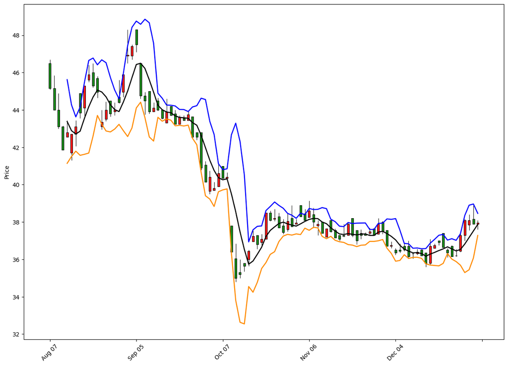

```python
import pandas as pd
import mplfinance as mpf
from talib import abstract

stocks = pd.read_csv('stocks_3169.csv')

stocks.iloc[:, 0] = pd.to_datetime(stocks.iloc[:, 0], format = "%d/%m/%Y")
stocks = stocks.set_index(pd.DatetimeIndex(stocks["Date"]))

stocks = stocks.tail(100)

colorSet = mpf.make_marketcolors(up = 'r', down = 'g', inherit = False)

styleSet = mpf.make_mpf_style(marketcolors = colorSet)

kwargs = dict(type = 'candle', style = styleSet, figscale = 2)

#Bollinger Bands
stock_BBands = stocks.copy() #複製資料
stock_BBands.columns = ['date', 'open', 'high', 'low', 'close', 'volume']
aBBands = abstract.BBANDS(stock_BBands) #talib內建方法

upper_bound  = aBBands['upperband']
middle_bound = aBBands['middleband']
lower_bound  = aBBands['lowerband']

apds = [
        mpf.make_addplot(upper_bound, color = 'blue'),
        mpf.make_addplot(middle_bound, color = 'black'),
        mpf.make_addplot(lower_bound, color = 'darkorange'),
       ]

mpf.plot(stock_BBands, **kwargs, addplot = apds)
```

# 1-7 繪製圖形 - KD指標

## KD指標定義：利用RSV進行加權計算、RSV表達"與最近N天相比今天股價是強還是弱？"

## KD指標公式：

### RSV = ( (今日收盤 - 最近N天最低價) / ( 最近N天最高價 - 最近N天最低價) )

### K = 2/3 *昨日K值 + 1/3* 今日RSV

### D = 2/3 *昨日D值 + 1/3* 今日K值

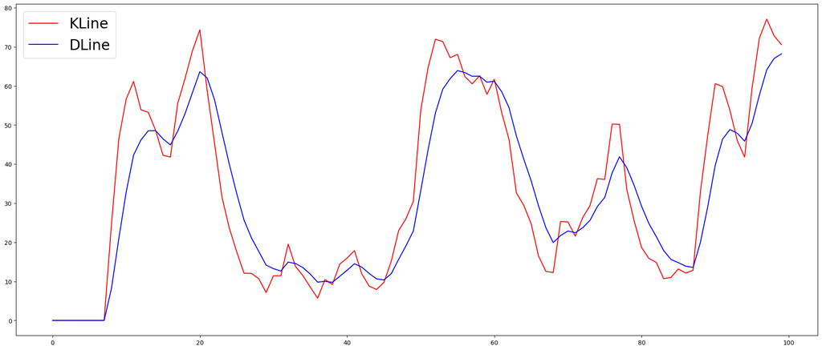

```python
import pandas as pd
import matplotlib.pyplot as plt

stocks = pd.read_csv('stocks_3169.csv')

stocks.iloc[:, 0] = pd.to_datetime(stocks.iloc[:, 0], format = "%d/%m/%Y")
stocks = stocks.set_index(pd.DatetimeIndex(stocks["Date"]))

stocks = stocks.tail(100)

#KD K為快線、D為慢線
stocks_close = [float(line) for line in stocks['Close']] #收盤價
stocks_high = [float(line) for line in stocks['High']]   #最高價
stocks_low = [float(line) for line in stocks['Low']]     #最低價
rsv = []                                                 #RSV list
Kpoint = [0]                                             #K值 list
Dpoint = [0]                                             #D值 list

#最近9天的 KD指標
#計算 RSV
for i in range(8, len(stocks_close)):
    low = min(stocks_low[i-8 : i+1])
    high = max(stocks_high[i-8 : i+1])
    rsv.append(round(100 * ((stocks_close[i] - low) / (high - low)), 2))

#計算K值和D值
for i in range(0, len(rsv)):
    Kpoint.append(round((Kpoint[i] * (2 / 3) + rsv[i] * (1 / 3)), 2))
    Dpoint.append(round((Dpoint[i] * (2 / 3) + Kpoint[i + 1] * (1 / 3)), 2))

#補齊元素個數，前 8項較不重要，所以補 0
for i in range(0, 7):
    Kpoint.insert(i, 0)
    Dpoint.insert(i, 0)

plt.figure(figsize = (24, 10))
plt.plot(Kpoint, label = 'KLine', color = 'red')
plt.plot(Dpoint, label = 'DLine', color = 'blue')
plt.legend(fontsize = 24)
plt.show()
```

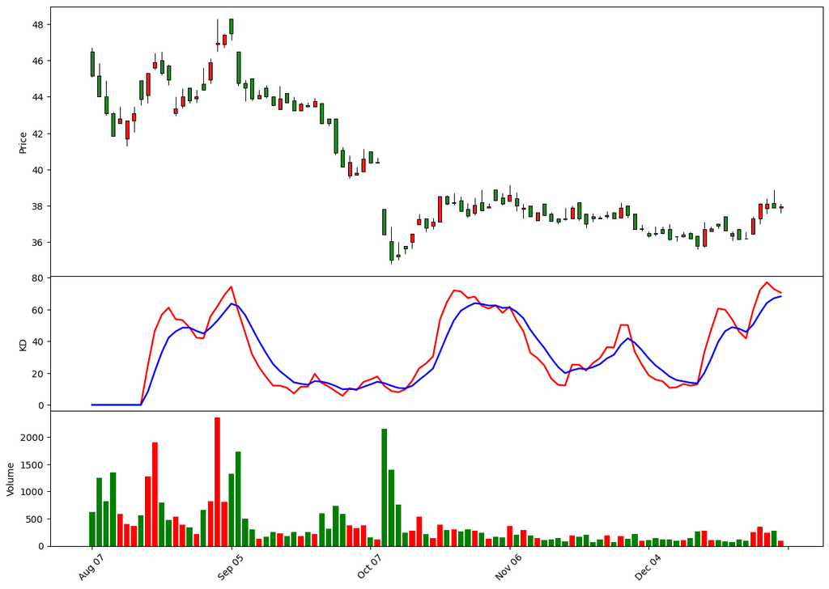

```python
import pandas as pd
import mplfinance as mpf

stocks = pd.read_csv('stocks_3169.csv')

stocks.iloc[:, 0] = pd.to_datetime(stocks.iloc[:, 0], format = "%d/%m/%Y")
stocks = stocks.set_index(pd.DatetimeIndex(stocks["Date"]))

stocks = stocks.tail(100)

colorSet = mpf.make_marketcolors(up = 'r', down = 'g', inherit = False)

styleSet = mpf.make_mpf_style(marketcolors = colorSet)

kwargs = dict(type = 'candle', style = styleSet, figscale = 2)

#KD K為快線、D為慢線
stocks_close = [float(line) for line in stocks['Close']] #收盤價
stocks_high = [float(line) for line in stocks['High']]   #最高價
stocks_low = [float(line) for line in stocks['Low']]     #最低價
rsv = []                                                 #RSV list
Kpoint = [0]                                             #K值 list
Dpoint = [0]                                             #D值 list

#最近9天的 KD指標
#計算 RSV
for i in range(8, len(stocks_close)):
    low = min(stocks_low[i-8 : i+1])
    high = max(stocks_high[i-8 : i+1])
    rsv.append(round(100 * ((stocks_close[i] - low) / (high - low)), 2))

#計算K值和D值
for i in range(0, len(rsv)):
    Kpoint.append(round((Kpoint[i] * (2 / 3) + rsv[i] * (1 / 3)), 2))
    Dpoint.append(round((Dpoint[i] * (2 / 3) + Kpoint[i + 1] * (1 / 3)), 2))

#補齊元素個數，前 8項較不重要，所以補 0
for i in range(0, 7):
    Kpoint.insert(i, 0)
    Dpoint.insert(i, 0)

#成交量分顏色
stocks_volume_red = []
stocks_volume_green = []

for i in range(0, len(stocks['Volume'])):
    if(stocks['Open'][i] < stocks['Close'][i]):
        stocks_volume_red.append(int(stocks['Volume'][i]))
    else:
        stocks_volume_red.append(0)
    if(stocks['Open'][i] >= stocks['Close'][i]):
        stocks_volume_green.append(int(stocks['Volume'][i]))
    else:
        stocks_volume_green.append(0)

draw = [
        mpf.make_addplot(Kpoint, panel = 1, color = 'red', ylabel = 'KD'),
        mpf.make_addplot(Dpoint, panel = 1, color = 'blue'),
        mpf.make_addplot(stocks_volume_red, type = 'bar', panel = 2, color = 'red', ylabel = 'Volume'),
        mpf.make_addplot(stocks_volume_green, type = 'bar', panel = 2, color = 'green')
       ]

mpf.plot(stocks, **kwargs, addplot = draw, panel_ratios = (4, 2, 2))
mpf.show()
```

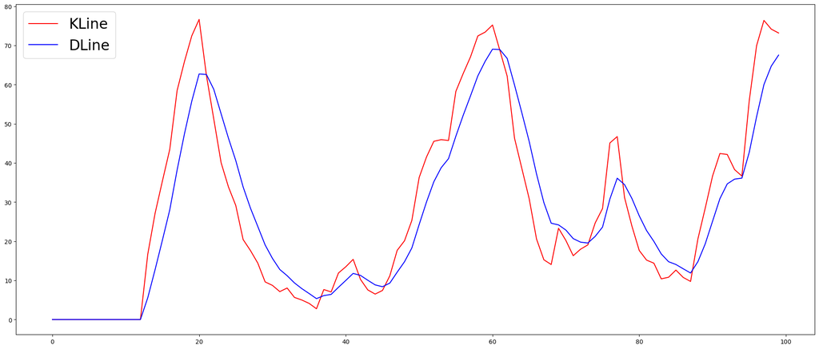

```python
import pandas as pd
import matplotlib.pyplot as plt

stocks = pd.read_csv('stocks_3169.csv')

stocks.iloc[:, 0] = pd.to_datetime(stocks.iloc[:, 0], format = "%d/%m/%Y")
stocks = stocks.set_index(pd.DatetimeIndex(stocks["Date"]))

stocks = stocks.tail(100)

#KD K為快線、D為慢線
stocks_close = [float(line) for line in stocks['Close']] #收盤價
stocks_high = [float(line) for line in stocks['High']]   #最高價
stocks_low = [float(line) for line in stocks['Low']]     #最低價
rsv = []                                                 #RSV list
Kpoint = [0]                                             #K值 list
Dpoint = [0]                                             #D值 list

#最近14天的 KD指標
#計算 RSV
for i in range(13, len(stocks_close)):
    low = min(stocks_low[i-13 : i+1])
    high = max(stocks_high[i-13 : i+1])
    rsv.append(round(100 * ((stocks_close[i] - low) / (high - low)), 2))

#計算K值和D值
for i in range(0, len(rsv)):
    Kpoint.append(round((Kpoint[i] * (2 / 3) + rsv[i] * (1 / 3)), 2))
    Dpoint.append(round((Dpoint[i] * (2 / 3) + Kpoint[i + 1] * (1 / 3)), 2))

#補齊元素個數，前 8項較不重要，所以補 0
for i in range(0, 12):
    Kpoint.insert(i, 0)
    Dpoint.insert(i, 0)

plt.figure(figsize = (24, 10))
plt.plot(Kpoint, label = 'KLine', color = 'red')
plt.plot(Dpoint, label = 'DLine', color = 'blue')
plt.legend(fontsize = 24)
plt.show()
```

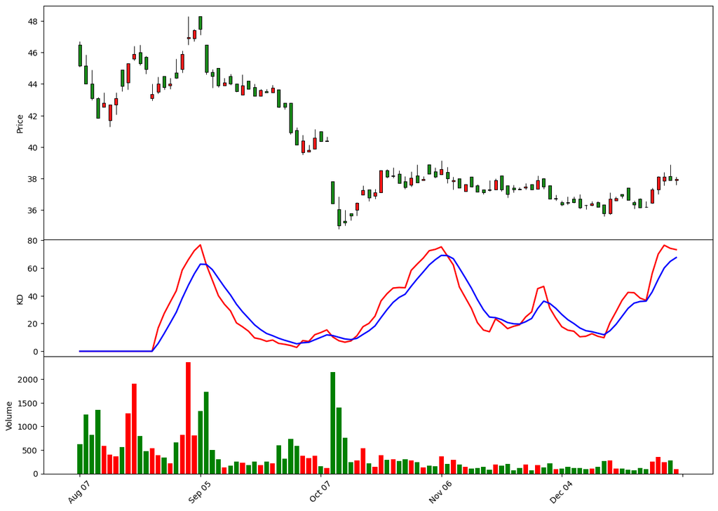

```python
import pandas as pd
import mplfinance as mpf

stocks = pd.read_csv('stocks_3169.csv')

stocks.iloc[:, 0] = pd.to_datetime(stocks.iloc[:, 0], format = "%d/%m/%Y")
stocks = stocks.set_index(pd.DatetimeIndex(stocks["Date"]))

stocks = stocks.tail(100)

colorSet = mpf.make_marketcolors(up = 'r', down = 'g', inherit = False)

styleSet = mpf.make_mpf_style(marketcolors = colorSet)

kwargs = dict(type = 'candle', style = styleSet, figscale = 2)

#KD K為快線、D為慢線
stocks_close = [float(line) for line in stocks['Close']] #收盤價
stocks_high = [float(line) for line in stocks['High']]   #最高價
stocks_low = [float(line) for line in stocks['Low']]     #最低價
rsv = []                                                 #RSV list
Kpoint = [0]                                             #K值 list
Dpoint = [0]                                             #D值 list

#最近14天的 KD指標
#計算 RSV
for i in range(13, len(stocks_close)):
    low = min(stocks_low[i-13 : i+1])
    high = max(stocks_high[i-13 : i+1])
    rsv.append(round(100 * ((stocks_close[i] - low) / (high - low)), 2))

#計算K值和D值
for i in range(0, len(rsv)):
    Kpoint.append(round((Kpoint[i] * (2 / 3) + rsv[i] * (1 / 3)), 2))
    Dpoint.append(round((Dpoint[i] * (2 / 3) + Kpoint[i + 1] * (1 / 3)), 2))

#補齊元素個數，前 13項較不重要，所以補 0
for i in range(0, 12):
    Kpoint.insert(i, 0)
    Dpoint.insert(i, 0)

#成交量分顏色
stocks_volume_red = []
stocks_volume_green = []

for i in range(0, len(stocks['Volume'])):
    if(stocks['Open'][i] < stocks['Close'][i]):
        stocks_volume_red.append(int(stocks['Volume'][i]))
    else:
        stocks_volume_red.append(0)
    if(stocks['Open'][i] >= stocks['Close'][i]):
        stocks_volume_green.append(int(stocks['Volume'][i]))
    else:
        stocks_volume_green.append(0)

draw = [
        mpf.make_addplot(Kpoint, panel = 1, color = 'red', ylabel = 'KD'),
        mpf.make_addplot(Dpoint, panel = 1, color = 'blue'),
        mpf.make_addplot(stocks_volume_red, type = 'bar', panel = 2, color = 'red', ylabel = 'Volume'),
        mpf.make_addplot(stocks_volume_green, type = 'bar', panel = 2, color = 'green')
       ]

mpf.plot(stocks, **kwargs, addplot = draw, panel_ratios = (4, 2, 2))
mpf.show()
```

# 1-8 如何標記點

## 標點範例

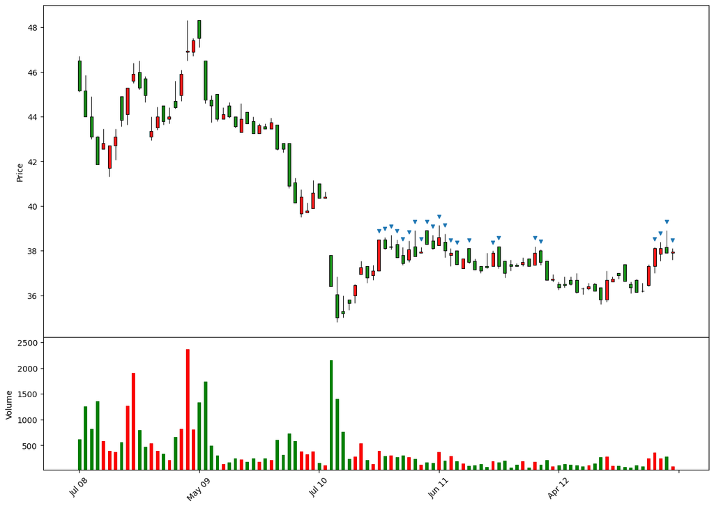

```python
import numpy as np
import pandas as pd
import mplfinance as mpf

stocks = pd.read_csv('stocks_3169.csv')

stocks = stocks.set_index(pd.DatetimeIndex(stocks["Date"]))
stocks.iloc[:, 0] = pd.to_datetime(stocks.iloc[:, 0], format = "%d/%m/%Y")

stocks = stocks.tail(100)

colorSet = mpf.make_marketcolors(up = 'r', down = 'g', volume = 'inherit')

styleSet = mpf.make_mpf_style(marketcolors = colorSet)

kwargs = dict(type = 'candle', volume = True, figscale = 2,
    style = styleSet, scale_width_adjustment = dict(volume = 0.5))

stocks_high = [float(line) for line in stocks["High"]]

#繪製點的方式
points = []
for i in range(0, len(stocks)):
    #最高價在38~40之間則標點
    if(38 <= stocks_high[i] and stocks_high[i] <= 40):
        points.append(stocks_high[i] * 1.01)
    else:
        points.append(np.nan)

#type要注意 是scatter，也有許多種 marker
addplots = mpf.make_addplot(points, type = 'scatter', marker = 'v')

mpf.plot(stocks, **kwargs, addplot = addplots)
```